# Ford gobike data analysis

## by Seifeldin Mostafa

## Investigation Overview

> The goal of this presentation is to provide some interesting insights from the Ford gobike data

## Dataset Overview

> The dataset contained detailed informations about trips made by Ford gobike users

## The most popular 20 bikes used by Ford gobike users

> The Leading bike used by Ford gobike is the one with bike_id `4794`

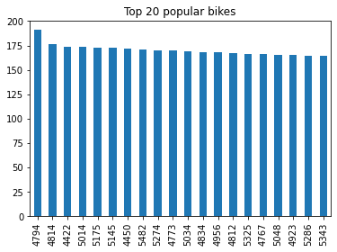

## Dive into the Ford gobike users types analysis

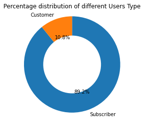

> This Figure shows that 10.8 % of our dataset user types are Customers, while the remaining 89.2% are Subscribers

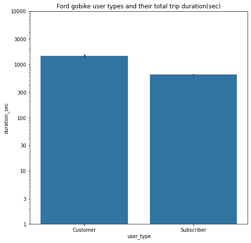

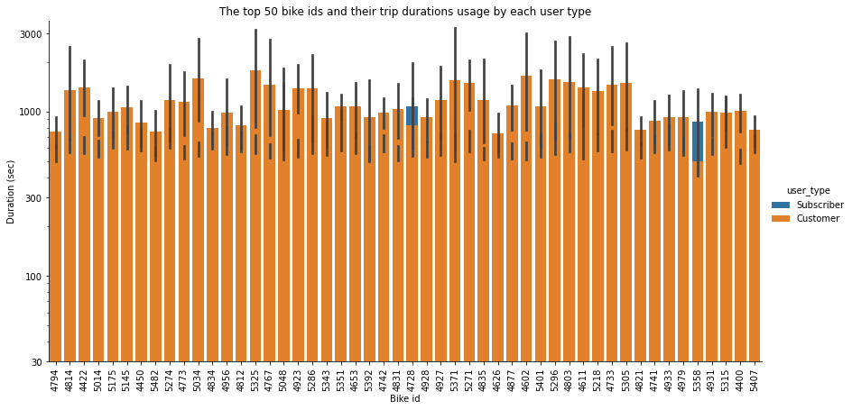

> As you can notice in this figure, the majority the top bikes ids with respect to the duration is mostly influenced by the `Customer` user type. So, if the plan is to boost the one-time customer segment of the Ford gobike, I would highly recommend availing the bike with id `5325`

*this should not be used to influence the business decisions for `Subscribers` ford gobike*

## Dive into the Ford gobike gender analysis

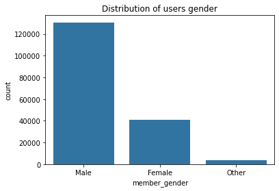

> This Figure shows that the majority of our dataset are Males, followed by a huge gap are Females then others

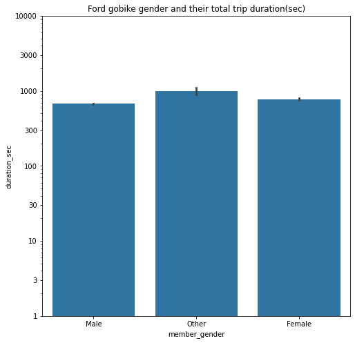

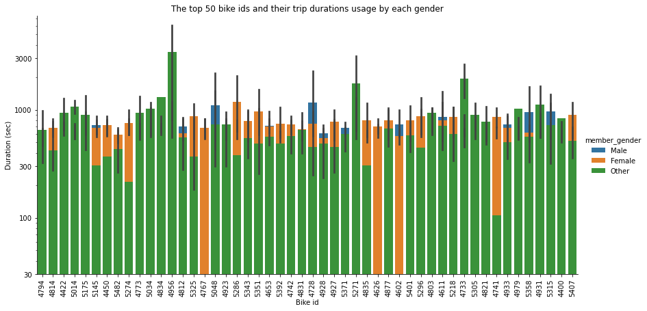

> As you can notice in this figure, the majority the top bikes ids with respect to the duration is mostly influenced by the Other gender. So, if the plan is to boost the other gender, I would highly recommend availing the bike with id 4956

*These bike ids are not to be used as a generalized bikes prefered for all ford gobike genders, the majority of our dataset are male users not others*

# The most popular starting and ending points for Ford gobike trips

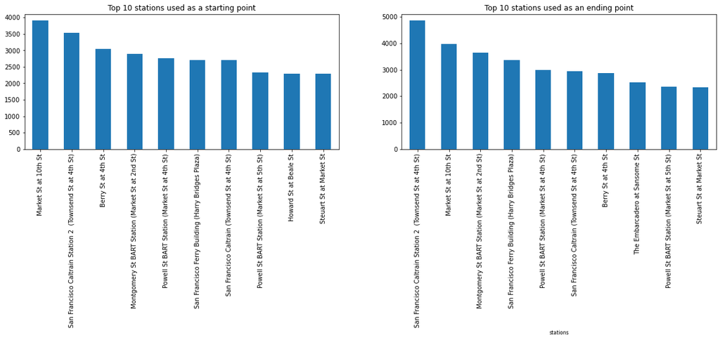

> `Market St at 10th St`and `San Fransisco Sation 2` are the top visited points by Ford Gobike users. These locations might be a great spot for marketing and brand awareness